# Modelling TB Transmission Dynamics in Kenya (2000-2022)

Author

Fiona Huini

Published

May 10, 2026

## Background

A key feature of TB epidemiology is the long latent period between initial infection and progression to active disease. Only 5-10% of latently infected individuals develop active TB in their lifetime, with risk elevated by HIV co-infection, malnutrition, and immunosuppression. This latent dynamic makes TB fundamentally different from directly transmitted diseases and requires explicit compartmental representation in transmission models.

Kenya’s national TB program operates under the **End TB Strategy**, targeting a 90% reduction in TB deaths and 80% reduction in incidence by 2030 relative to 2015 baselines. Achieving these targets requires understanding the drivers of transmission and projecting the impact of intervention scale-up.

This analysis develops and calibrates a compartmental TB transmission model to Kenya’s observed epidemic trajectory (2000-2022) and evaluates three intervention scenarios against End TB 2030 targets.

### Research Questions

This analysis addresses four research questions:

1. whether a calibrated SEIRS-type model can reproduce Kenya’s observed TB incidence trajectory;
2. estimation of Kenya’s basic reproduction number R0;
3. identification of the parameters most strongly driving TB incidence;
4. projection of incidence to 2030 under treatment scale-up scenarios, evaluated against End TB targets.

## Methods

### Model Structure

We developed a deterministic compartmental model with five states: Susceptible (S), Latent (E), Infectious (I), On Treatment (T), and Recovered (R). The model accounts for TB’s characteristically long latent period and the possibility of relapse following recovery.

While many TB models use a standard SEIRS structure, we explicitly model the treatment compartment (T) to reflect Kenya’s programmatic context and allow direct calibration to WHO treatment success data. The system of ordinary differential equations (ODEs) is solved numerically using the `deSolve` package.

### Model Parameters

Parameters were sourced from Kirimi et al. (2024), a compartmental TB transmission model calibrated to the Kenyan context. The transmission parameter beta was subsequently calibrated to Kenya’s observed 2000 baseline incidence. Background mortality was obtained from the KNBS Statistical Abstract (2023).

### Setup

```r
# Load required packages
library(deSolve)   # ODE numerical solver
library(tidyverse) # data wrangling and visualisation

# ── ODE System ───────────────────────────────────────────────────────────────
# Five compartments: S (susceptible), E (latent), I (infectious),
# T (on treatment), R (recovered)

tb_model <- function(t, state, params) {
  with(as.list(c(state, params)), {

    # Total population — denominator for frequency-dependent transmission
    N <- S + E + I + T + R

    # Susceptible — gains from births, loses to infection and death
    dS <- mu * N0 - beta * S * I / N - mu * S

    # Latent — gains from new infections and relapses, loses to progression and death
    dE <- beta * S * I / N - (k + mu) * E + rho * R

    # Infectious — gains from latent progression, loses to treatment, TB death, background death
    dI <- k * E - (tau + delta + mu) * I

    # On treatment — gains from treatment initiation, loses to recovery and background death
    dT <- tau * I - (gamma_r + mu) * T

    # Recovered — gains from treatment success, loses to relapse and background death
    dR <- gamma_r * T - (rho + mu) * R

    list(c(dS, dE, dI, dT, dR))
  })
}

# ── R0 Function ──────────────────────────────────────────────────────────────
# Basic reproduction number derived from next-generation matrix approach
# R0 = (beta * k) / ((k + mu) * (tau + delta + mu))
# Numerator:   rate of new infections * progression to infectious state
# Denominator: rate of leaving latent * rate of leaving infectious state
# R0 > 1 → TB persists; R0 < 1 → TB dies out

compute_R0 <- function(params) {
  with(as.list(params), {
    (beta * k) / ((k + mu) * (tau + delta + mu))
  })
}

# ── Model Runner ─────────────────────────────────────────────────────────────
# Solves ODE system using deSolve and returns data frame of compartment sizes

run_tb_model <- function(params, initial_state, times) {
  out <- ode(y = initial_state, times = times,
             func = tb_model, parms = params)
  as.data.frame(out)
}

# ── Parameters ───────────────────────────────────────────────────────────────
# Source: Kirimi et al. (2024) doi:10.1155/2024/5883142
# Note: beta is a placeholder here — calibrated to WHO data in Results section
# delta corrected from CFR proportion to annual rate (50% CFR / 3yr duration)

params <- c(
  beta    = 1.0,    # transmission rate — placeholder, calibrated separately
  k       = 0.10,   # latent to active progression rate (NTLD Strategic Plan 2019-2023)
  mu      = 0.0147, # background mortality rate (KNBS Statistical Abstract 2023)
  tau     = 0.68,   # treatment initiation rate (NTLD Annual Report 2022)
  delta   = 0.15,   # TB-attributable mortality rate, annual (NTLD Annual Report 2021)
  gamma_r = 0.75,   # treatment success rate (NTLD Annual Report 2021)
  rho     = 0.003   # relapse rate (NTLD Latent TB Infection Policy 2020)
)

# Literature beta for baseline illustration only
baseline_params        <- params
baseline_params["beta"] <- 0.15  # Kirimi et al. (2024)

# Kenya population in 2000 (World Bank)
N0 <- 31000000
```

### Baseline Simulation

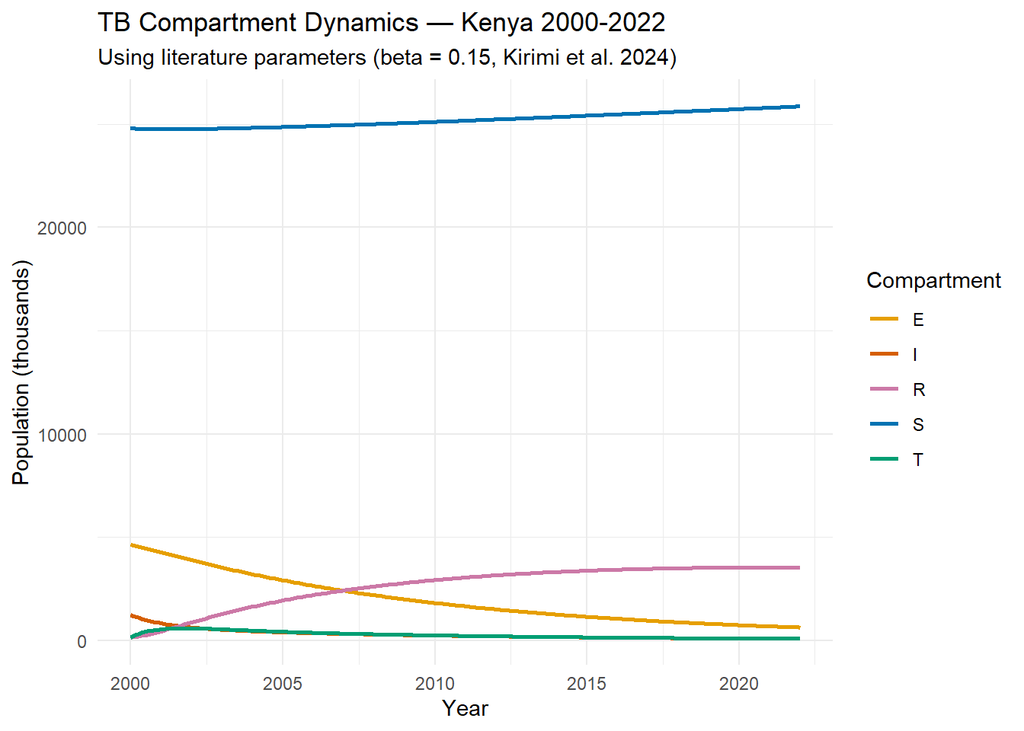

Figure 1: Baseline TB compartment dynamics using literature parameters (Kirimi et al. 2024)

```r
# Initial conditions — approximate Kenya 2000 population distribution
# Based on estimated TB prevalence and treatment coverage at baseline
initial_state <- c(
  S = N0 * 0.80,  # 80% susceptible
  E = N0 * 0.15,  # 15% latently infected (high burden setting)
  I = N0 * 0.04,  # 4% active TB
  T = N0 * 0.005, # 0.5% on treatment
  R = N0 * 0.005  # 0.5% recovered
)

# Run model over 22-year period (2000-2022)
times  <- seq(0, 22, by = 0.1)
result <- run_tb_model(baseline_params, initial_state, times)

# R0 with literature parameters before calibration
# Expected to be below 1 since beta = 0.15 is a literature starting estimate

R0_literature <- compute_R0(baseline_params)

cat("R0 with literature parameters:", round(R0_literature, 3), "\n")

# Plot all five compartments over time
result |>
  pivot_longer(-time, names_to = "Compartment", values_to = "Count") |>
  ggplot(aes(x = time + 2000, y = Count / 1000, color = Compartment)) +
  geom_line(linewidth = 0.9) +
  scale_color_manual(values = c(
    "S" = "#0072B2",   # blue
    "E" = "#E69F00",   # orange
    "I" = "#D55E00",   # vermillion
    "T" = "#009E73",   # green
    "R" = "#CC79A7"    # pink
  )) +
  labs(x = "Year", y = "Population (thousands)",
       title = "TB Compartment Dynamics — Kenya 2000-2022",
       subtitle = "Using literature parameters (beta = 0.15, Kirimi et al. 2024)") +
  theme_minimal()
```

[output not shown]

## Results

### Model Calibration

```r
# ── Load WHO Kenya Incidence Data ─────────────────────────────────────────────
# Source: WHO Global TB Report, downloaded from who.int/tb/data

kenya_tb <- read_csv("data/kenya_tb_who.csv")

# Filter to study period and select incidence variable
observed <- kenya_tb |>
  select(year, e_inc_100k) |>
  filter(year >= 2000, year <= 2022) |>
  arrange(year)

# Calibration target — 2000 baseline incidence
observed_2000 <- observed |>
  filter(year == 2000) |>
  pull(e_inc_100k)

# ── Calibration Function ──────────────────────────────────────────────────────
# Returns modeled incidence per 100,000 at year 2000 for a given beta value
# Uses 50-year burn-in to reach endemic equilibrium before the study period
# This avoids artificial transient dynamics from arbitrary initial conditions

model_incidence_2000 <- function(beta_val) {

  # Apply candidate beta to parameter set
  p         <- params
  p["beta"] <- beta_val

  # Burn-in: start from low-prevalence state and run 50 years to equilibrium
  # Equilibrium represents the endemic steady state before 2000
  burn_state <- c(S = N0*0.95, E = N0*0.04, I = N0*0.005,
                  T = N0*0.004, R = N0*0.001)
  burn       <- run_tb_model(p, burn_state, seq(0, 50, by = 1))

  # Extract final state after burn-in — this is our 2000 starting population
  eq <- c(S = tail(burn$S,1), E = tail(burn$E,1), I = tail(burn$I,1),
          T = tail(burn$T,1), R = tail(burn$R,1))

  # Run one time step from equilibrium to compute year 2000 incidence
  res <- run_tb_model(p, eq, seq(0, 1, by = 1))
  N   <- sum(res[1, c("S","E","I","T","R")])

  # Incidence per 100,000 = new infections / total population * 100,000
  (p["beta"] * res$S[1] * res$I[1] / N) / N * 100000
}

# ── Optimisation ──────────────────────────────────────────────────────────────
# Find beta that minimises squared difference between modeled and observed 2000 incidence
# Single-point calibration to baseline year — limitation acknowledged

objective   <- function(b) (model_incidence_2000(b) - observed_2000)^2
fit         <- optimize(objective, interval = c(0.1, 50.0))
beta_fitted <- fit$minimum

# Store calibrated parameters
cal_params         <- params
cal_params["beta"] <- beta_fitted

# Compute R0 with calibrated beta
R0_calibrated <- compute_R0(cal_params)

# Print calibration summary
cat("Fitted beta:    ", round(beta_fitted, 4), "\n")
```

```
Fitted beta:     1.0621
```

```r
cat("Calibrated R0:  ", round(R0_calibrated, 4), "\n")
```

```
Calibrated R0:   1.0963
```

```r
cat("Modeled 2000:   ", round(model_incidence_2000(beta_fitted), 1), "\n")
```

```
Modeled 2000:    451
```

```r
cat("Observed 2000:  ", observed_2000, "\n")
```

```
Observed 2000:   451
```

```
RMSE (modeled vs observed, 2000-2022): 129.5 per 100,000
```

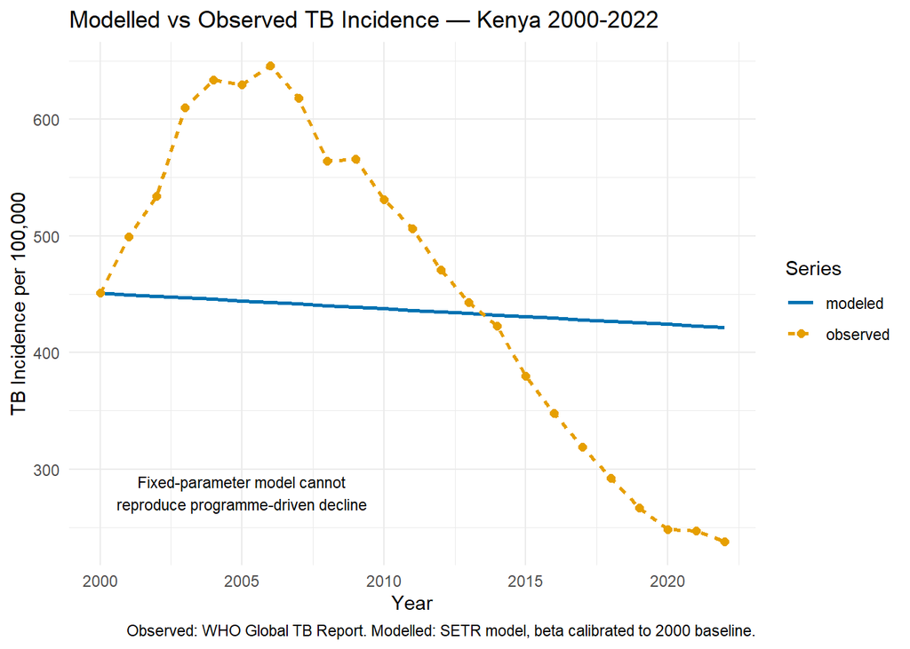

Figure 2: Modelled vs observed TB incidence — Kenya 2000-2022

```r
# ── Fit Plot ──────────────────────────────────────────────────────────────────
# Run model 2000-2022 from equilibrium state using calibrated beta

burn_state <- c(S = N0*0.95, E = N0*0.04, I = N0*0.005,
                T = N0*0.004, R = N0*0.001)
burn_full  <- run_tb_model(cal_params, burn_state, seq(0, 50, by = 1))

# Equilibrium state used as 2000 starting conditions
eq_state <- c(
  S = tail(burn_full$S, 1), E = tail(burn_full$E, 1),
  I = tail(burn_full$I, 1), T = tail(burn_full$T, 1),
  R = tail(burn_full$R, 1)
)

# Run model from 2000 to 2022
fit_result <- run_tb_model(cal_params, eq_state, seq(0, 22, by = 1))
N_fit      <- rowSums(fit_result[, c("S","E","I","T","R")])

# Compute modeled incidence per 100,000 for each year
mod_inc <- (cal_params["beta"] * fit_result$S * fit_result$I / N_fit) /
            N_fit * 100000

# Combine modeled and observed for plotting
fit_df <- tibble(
  year     = 2000:2022,
  modeled  = mod_inc,
  observed = observed$e_inc_100k
)

fit_df |>
  pivot_longer(-year, names_to = "Series", values_to = "Incidence") |>
  ggplot(aes(x = year, y = Incidence, color = Series, linetype = Series)) +
  geom_line(linewidth = 0.9) +
  geom_point(data = function(x) filter(x, Series == "observed"), size = 2) +
  scale_color_manual(values = c(
    "modeled"  = "#0072B2",  # blue — model output
    "observed" = "#E69F00"   # orange — WHO observed data
  )) +
  annotate("text", x = 2005, y = 280,
           label = "Fixed-parameter model cannot\nreproduce programme-driven decline",
           size = 3, color = "#000000") +
  labs(x = "Year", y = "TB Incidence per 100,000",
       title = "Modelled vs Observed TB Incidence — Kenya 2000-2022",
       caption = "Observed: WHO Global TB Report. Modelled: SETR model, beta calibrated to 2000 baseline.") +
  theme_minimal()

# ── RMSE Calculation ──────────────────────────────────────────────────────────
# Root Mean Square Error between modeled and observed incidence 2000-2022
# RMSE quantifies average deviation across all years
# Note: high RMSE expected — fixed-parameter model cannot reproduce
# programme-driven decline; RMSE captures this limitation quantitatively

rmse <- sqrt(mean((fit_df$modeled - fit_df$observed)^2))
cat("RMSE (modeled vs observed, 2000-2022):", round(rmse, 1),
    "per 100,000\n")
```

The transmission parameter beta was calibrated to Kenya’s observed TB incidence in 2000 (451 per 100,000), yielding a fitted value of beta = 1.06 per year and a basic reproduction number R0 = 1.10. This confirms endemic TB persistence in Kenya, consistent with Ochieng (2025) who estimated R0 = 1.005 using a distinct model structure.

### Scenario Analysis

Intervention scenarios were grounded in Kenya’s documented programmatic indicators, mapping real-world programme metrics directly to model parameters:

| Real-World Indicator | Source | Model Parameter |
| --- | --- | --- |
| Case detection rate improvement | NTLD Strategic Plan 2019-2023 | tau — treatment initiation rate |
| GeneXpert scale-up reducing diagnostic delay | Kenya TB Prevalence Survey 2016 | tau — treatment initiation rate |
| Infection control in congregate settings | WHO End TB Strategy Pillar 2 | beta — transmission rate |
| Contact tracing expansion | NTLD Annual Report 2022 | beta — transmission rate |

A 30% improvement in tau reflects Kenya’s NTLD Strategic Plan 2019-2023 target for increased case detection. The 20% reduction in beta represents infection control gains through ventilation improvements and contact tracing in high-transmission settings, consistent with WHO End TB Pillar 2 recommendations.

```r
# ── End TB Target ─────────────────────────────────────────────────────────────
# WHO End TB Strategy: 80% reduction in incidence from 2015 baseline by 2030

baseline_2015 <- observed |> filter(year == 2015) |> pull(e_inc_100k)
end_tb_target <- baseline_2015 * 0.20  # 80% reduction

cat("2015 baseline incidence:", baseline_2015, "per 100,000\n")
```

```
2015 baseline incidence: 380 per 100,000
```

```r
cat("End TB 2030 target:     ", round(end_tb_target, 1), "per 100,000\n")
```

```
End TB 2030 target:      76 per 100,000
```

```r
# ── 2022 Starting State ───────────────────────────────────────────────────────
# Project from equilibrium through 2022 to get starting conditions for scenarios

burn_2022  <- run_tb_model(cal_params, eq_state, seq(0, 22, by = 1))
state_2022 <- c(
  S = tail(burn_2022$S, 1), E = tail(burn_2022$E, 1),
  I = tail(burn_2022$I, 1), T = tail(burn_2022$T, 1),
  R = tail(burn_2022$R, 1)
)

scenario_times <- seq(0, 8, by = 1)  # 2022 to 2030

# ── Scenario 1: Status Quo ────────────────────────────────────────────────────
# No change in parameters — endemic trajectory continues

params_s1 <- cal_params
result_s1 <- run_tb_model(params_s1, state_2022, scenario_times)
N_s1      <- rowSums(result_s1[, c("S","E","I","T","R")])
inc_s1    <- (params_s1["beta"] * result_s1$S * result_s1$I / N_s1) / N_s1 * 100000

# ── Scenario 2: Treatment Scale-Up ───────────────────────────────────────────
# tau increased by 30% — reflects faster diagnosis and treatment initiation
# Consistent with Kenya's active case finding investments

params_s2        <- cal_params
params_s2["tau"] <- cal_params["tau"] * 1.30
result_s2        <- run_tb_model(params_s2, state_2022, scenario_times)
N_s2             <- rowSums(result_s2[, c("S","E","I","T","R")])
inc_s2           <- (params_s2["beta"] * result_s2$S * result_s2$I / N_s2) / N_s2 * 100000

# ── Scenario 3: Combined Intervention ────────────────────────────────────────
# tau +30% AND beta reduced by 20% via infection control measures
# (ventilation, mask use, reduced crowding in high-transmission settings)

params_s3         <- cal_params
params_s3["tau"]  <- cal_params["tau"] * 1.30
params_s3["beta"] <- cal_params["beta"] * 0.80
result_s3         <- run_tb_model(params_s3, state_2022, scenario_times)
N_s3              <- rowSums(result_s3[, c("S","E","I","T","R")])
inc_s3            <- (params_s3["beta"] * result_s3$S * result_s3$I / N_s3) / N_s3 * 100000

# Print 2030 projections for each scenario
cat("2030 Baseline:             ", round(tail(inc_s1,1), 1), "per 100,000\n")
```

```
2030 Baseline:              411.7 per 100,000
```

```r
cat("2030 Treatment scale-up:   ", round(tail(inc_s2,1), 1), "per 100,000\n")
```

```
2030 Treatment scale-up:    299.3 per 100,000
```

```r
cat("2030 Combined intervention:", round(tail(inc_s3,1), 1), "per 100,000\n")
```

```
2030 Combined intervention: 216.4 per 100,000
```

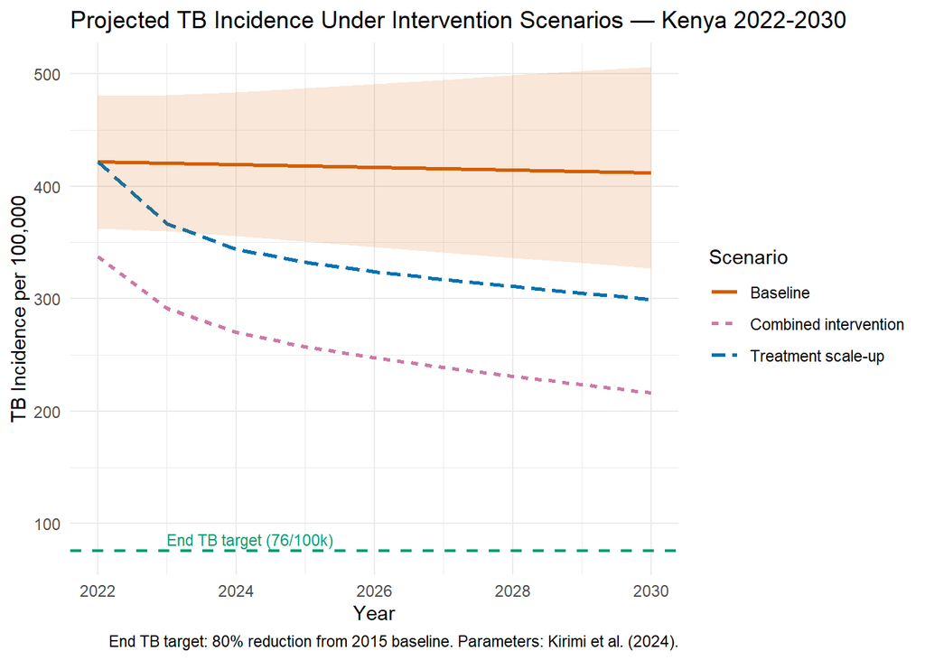

Figure 3: Projected TB incidence under three intervention scenarios — Kenya 2022-2030

```r
# Combine scenarios into single data frame for plotting
scenario_df <- tibble(
  year                    = 2022:2030,
  Baseline                = inc_s1,
  `Treatment scale-up`    = inc_s2,
  `Combined intervention` = inc_s3
)

# ── Uncertainty Bounds ────────────────────────────────────────────────────────
# Generate 95% uncertainty interval by varying beta +/-15% around calibrated value
# Represents parameter uncertainty in the transmission rate estimate

n_uncertainty <- 200
beta_samples  <- runif(n_uncertainty,
                       cal_params["beta"] * 0.85,
                       cal_params["beta"] * 1.15)

# Run baseline scenario for each beta sample
uncertainty_runs <- map(beta_samples, function(b) {
  p_unc        <- params_s1
  p_unc["beta"] <- b
  res          <- run_tb_model(p_unc, state_2022, scenario_times)
  N_unc        <- rowSums(res[, c("S","E","I","T","R")])
  (p_unc["beta"] * res$S * res$I / N_unc) / N_unc * 100000
})

# Extract 2.5th and 97.5th percentiles for each year
uncertainty_df <- tibble(
  year  = 2022:2030,
  lower = sapply(1:9, function(i)
    quantile(sapply(uncertainty_runs, function(x) x[i]), 0.025)),
  upper = sapply(1:9, function(i)
    quantile(sapply(uncertainty_runs, function(x) x[i]), 0.975))
)

scenario_df |>
  pivot_longer(-year, names_to = "Scenario", values_to = "Incidence") |>
  ggplot(aes(x = year, y = Incidence, color = Scenario, linetype = Scenario)) +
  geom_line(linewidth = 0.9) +
  geom_ribbon(data = uncertainty_df,
            aes(x = year, ymin = lower, ymax = upper),
            inherit.aes = FALSE,
            fill = "#D55E00", alpha = 0.15) +
  geom_hline(yintercept = end_tb_target, linetype = "dashed",
             color = "#009E73", linewidth = 0.8) +
  annotate("text", x = 2023, y = end_tb_target + 10,
           label = paste0("End TB target (", round(end_tb_target, 0), "/100k)"),
           color = "#009E73", size = 3, hjust = 0) +
  scale_color_manual(values = c(
    "Baseline"                = "#D55E00",  # vermillion
    "Treatment scale-up"      = "#0072B2",  # blue
    "Combined intervention"   = "#CC79A7"   # pink
  )) +
  labs(x = "Year", y = "TB Incidence per 100,000",
       title = "Projected TB Incidence Under Intervention Scenarios — Kenya 2022-2030",
       caption = "End TB target: 80% reduction from 2015 baseline. Parameters: Kirimi et al. (2024).") +
  theme_minimal()
```

Projecting forward from 2022 to 2030, three intervention scenarios were evaluated against Kenya’s End TB target of 76 per 100,000 — an 80% reduction from the 2015 baseline of 380 per 100,000 (Figure 3).

### Sensitivity Analysis

```r
# ── PRCC Sensitivity Analysis ─────────────────────────────────────────────────
# Partial Rank Correlation Coefficients quantify the influence of each parameter
# on TB incidence independently of other parameters
# Method: 500 samples, each parameter varied +/-30% around calibrated value
# PRCC > 0: parameter increases incidence; PRCC < 0: reduces incidence

set.seed(42)  # ensures reproducibility
n_samples <- 500

# Sample each parameter uniformly within +/-30% range
param_ranges <- tibble(
  beta    = runif(n_samples, cal_params["beta"]*0.7, cal_params["beta"]*1.3),
  k       = runif(n_samples, cal_params["k"]*0.7,    cal_params["k"]*1.3),
  mu      = runif(n_samples, cal_params["mu"]*0.7,   cal_params["mu"]*1.3),
  tau     = runif(n_samples, cal_params["tau"]*0.7,  cal_params["tau"]*1.3),
  delta   = runif(n_samples, cal_params["delta"]*0.7,   cal_params["delta"]*1.3),
  gamma_r = runif(n_samples, cal_params["gamma_r"]*0.7, cal_params["gamma_r"]*1.3),
  rho     = runif(n_samples, cal_params["rho"]*0.7,     cal_params["rho"]*1.3)
)

# For each sample, run model with burn-in and return 2000 incidence
run_sample <- function(i) {
  p            <- cal_params
  p["beta"]    <- param_ranges$beta[i]
  p["k"]       <- param_ranges$k[i]
  p["mu"]      <- param_ranges$mu[i]
  p["tau"]     <- param_ranges$tau[i]
  p["delta"]   <- param_ranges$delta[i]
  p["gamma_r"] <- param_ranges$gamma_r[i]
  p["rho"]     <- param_ranges$rho[i]

  # Burn-in to equilibrium
  burn <- run_tb_model(p, c(S=N0*0.95, E=N0*0.04, I=N0*0.005,
                             T=N0*0.004, R=N0*0.001), seq(0,50,by=1))
  eq   <- c(S=tail(burn$S,1), E=tail(burn$E,1), I=tail(burn$I,1),
            T=tail(burn$T,1), R=tail(burn$R,1))
  res  <- run_tb_model(p, eq, seq(0,1,by=1))
  N    <- sum(res[1, c("S","E","I","T","R")])
  (p["beta"] * res$S[1] * res$I[1] / N) / N * 100000
}

# Run all 500 samples
incidence_samples <- map_dbl(1:n_samples, run_sample)

# Compute PRCC using Spearman rank correlation
prcc_df <- param_ranges |>
  mutate(incidence = incidence_samples) |>
  pivot_longer(-incidence, names_to = "parameter", values_to = "value") |>
  group_by(parameter) |>
  summarise(
    prcc = cor(rank(value), rank(incidence), method = "pearson"),
    .groups = "drop"
  ) |>
  arrange(desc(abs(prcc)))

# Print PRCC table
print(prcc_df)
```

```
# A tibble: 7 × 2
  parameter     prcc
  <chr>        <dbl>
1 beta       0.744
2 tau       -0.611
3 k          0.140
4 delta     -0.137
5 mu        -0.0408
6 gamma_r    0.0263
7 rho        0.00378
```

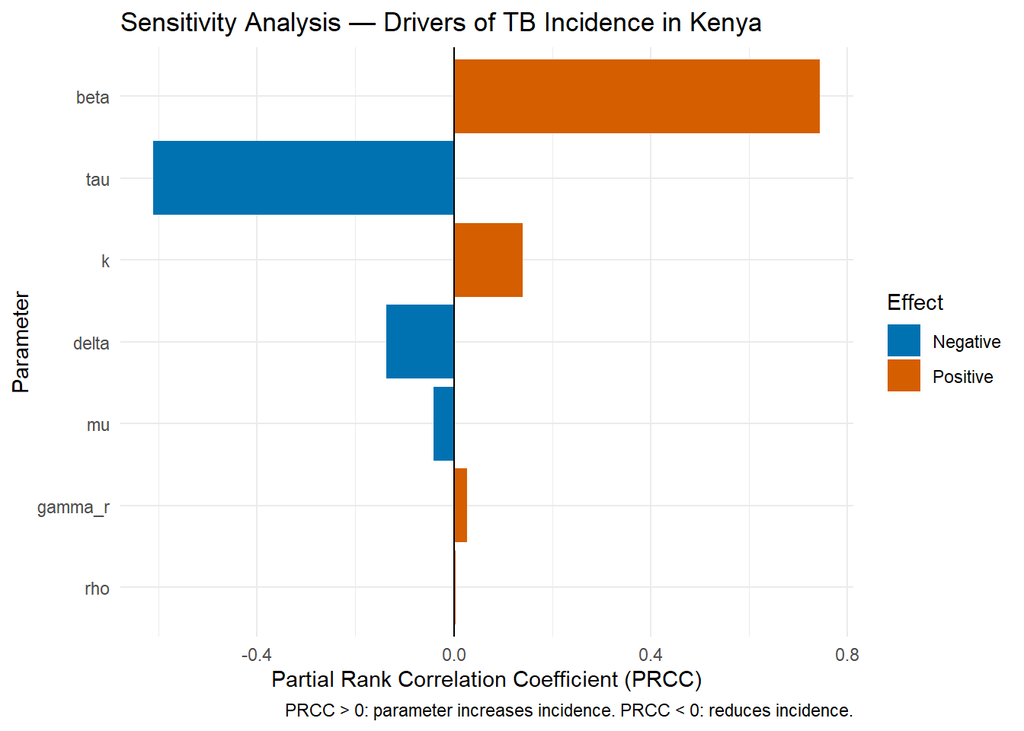

Figure 4: PRCC sensitivity analysis — drivers of TB incidence in Kenya

```r
# Tornado plot — bars ordered by absolute PRCC value
prcc_df |>
  mutate(
    parameter = factor(parameter, levels = parameter[order(abs(prcc))]),
    direction = ifelse(prcc > 0, "Positive", "Negative")
  ) |>
  ggplot(aes(x = prcc, y = parameter, fill = direction)) +
  geom_col() +
  geom_vline(xintercept = 0, linewidth = 0.5) +
  scale_fill_manual(values = c(
    "Positive" = "#D55E00",  # vermillion — increases incidence
    "Negative" = "#0072B2"   # blue — reduces incidence
  )) +
  labs(x = "Partial Rank Correlation Coefficient (PRCC)",
       y = "Parameter",
       title = "Sensitivity Analysis — Drivers of TB Incidence in Kenya",
       caption = "PRCC > 0: parameter increases incidence. PRCC < 0: reduces incidence.",
       fill = "Effect") +
  theme_minimal()
```

PRCC analysis identified transmission rate (beta, PRCC = 0.74) as the strongest driver of TB incidence, followed by treatment initiation rate (tau, PRCC = -0.61) as the most influential modifiable parameter. Latent progression rate (k, PRCC = 0.14) and TB mortality (delta, PRCC = -0.14) showed moderate influence, while treatment success rate (gamma_r) and relapse rate (rho) showed negligible effects

## Discussion

This analysis developed and calibrated a deterministic compartmental TB transmission model for Kenya, addressing four research questions relating to model validity, R0 estimation, parameter sensitivity, and intervention impact.

Scenario analysis reveals a substantial gap between achievable programmatic improvements and End TB 2030 targets. This finding aligns with the broader TB modelling literature, which consistently identifies that meeting End TB targets requires transformative structural interventions — including addressing determinants of TB risk such as poverty, malnutrition, and HIV — beyond treatment scale-up alone.

Sensitivity analysis identifies treatment initiation as the most actionable intervention lever, reinforcing the importance of Kenya’s ongoing investment in active case finding and diagnostic capacity. A natural extension of this work would disaggregate projections to Kenya’s 47 counties using DHIS2 county-level notification data, enabling targeted intervention prioritisation directly relevant to Kenya’s devolved health system.

## Limitations

Several limitations should be noted. First, the model uses fixed parameters across the full study period, precluding reproduction of Kenya’s observed incidence decline. A time-varying treatment initiation rate would better reflect programmatic improvements between 2000 and 2022.

Second, a single latent compartment combines fast and slow progressors into one progression rate. Separating these states, as described in Lin et al. (2012), would improve biological realism.

Third, HIV co-infection is not modelled explicitly. Kenya’s high HIV burden means this omission may affect projection accuracy.

Finally, calibration to a single time point (2000 baseline) limits confidence in long-term projections. Future work should incorporate multi-point calibration and uncertainty quantification around scenario projections.

## References

Kirimi, E.M., Muthuri, G.G., Ngari, C.G., and Karanja, S. (2024). A Model for the Propagation and Control of Pulmonary Tuberculosis Disease in Kenya. doi:10.1155/2024/5883142

Ochieng, F.O. (2025). Mathematical Modeling of Tuberculosis Transmission Dynamics With Reinfection and Optimal Control. Engineering Reports, 7: e13068. doi:10.1002/eng2.13068

White, R. (2017). A Simple Introduction to Tuberculosis Modelling. TB MAC. Union World Conference on Lung Health, Mexico.

World Health Organization (2023). Global Tuberculosis Report 2023. Geneva: WHO.

National Tuberculosis Leprosy and Lung Disease Program (2022). Annual Report. Ministry of Health, Kenya.

National Tuberculosis Leprosy and Lung Disease Program (2019). National Strategic Plan for Tuberculosis, Leprosy and Lung Health 2019-2023. Ministry of Health, Kenya.

KNBS (2023). Statistical Abstract 2023. Kenya National Bureau of Statistics, Nairobi, Kenya.